# Reproducible Research Assignment 1

Ruth

January 19, 2018

## Reading the Data

```r
getwd()
```

```
## [1] "C:/Users/Prisuser.PRIS-LT000120/Documents/Coursera/R_Programming"
```

```r
setwd(dir = "/Users/Prisuser.PRIS-LT000120/Documents/Coursera")
library(tidyr)
library(plyr)
library(dplyr)
```

```r
library(ggplot2)
data=read.csv("activity.csv", header=TRUE)
```

## Exploring Data on the Total Number of Steps Taken Daily

1. Total number of steps taken per day is as shown below:

```r
df<-aggregate(data$steps, by=list(date=data$date),FUN=sum, na.rm=TRUE)
names(df)<-c("Date(yyyy-mm-dd)","Number_of_Steps_Taken")
df
```

```
##    Date(yyyy-mm-dd) Number_of_Steps_Taken
## 1        2012-10-01                     0
## 2        2012-10-02                   126
## 3        2012-10-03                 11352
## 4        2012-10-04                 12116
## 5        2012-10-05                 13294
## 6        2012-10-06                 15420
## 7        2012-10-07                 11015
## 8        2012-10-08                     0
## 9        2012-10-09                 12811
## 10       2012-10-10                  9900
## 11       2012-10-11                 10304
## 12       2012-10-12                 17382
## 13       2012-10-13                 12426
## 14       2012-10-14                 15098
```

[output cut: 47 more lines]

2. Histogram of the Total Number of Steps Taken Daily

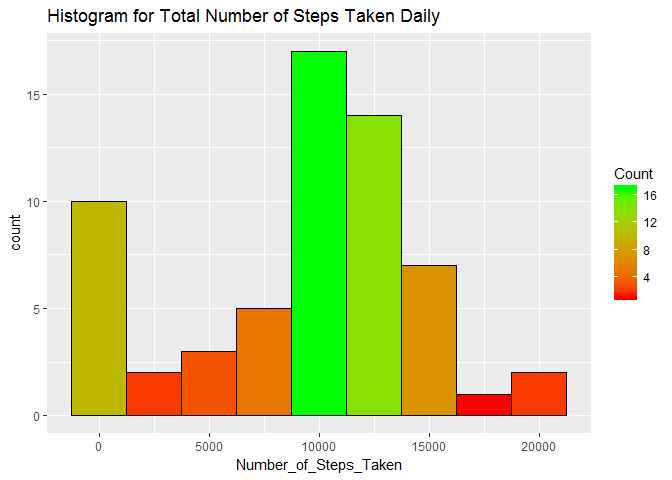

```r
g<-ggplot(data=df,aes(Number_of_Steps_Taken))+
  geom_histogram(col="black",aes(fill=..count..),binwidth = 2500)+
  scale_fill_gradient("Count",low="red",high="green")+
  labs(title="Histogram for Total Number of Steps Taken Daily")

print(g)
```

3a) Mean number of steps taken daily

```r
mean(df$Number_of_Steps_Taken)
```

```
## [1] 9354.23
```

3b) Median number of steps taken daily

```r
median(df$Number_of_Steps_Taken)
```

```
## [1] 10395
```

## Looking at Average Daily Activity Pattern

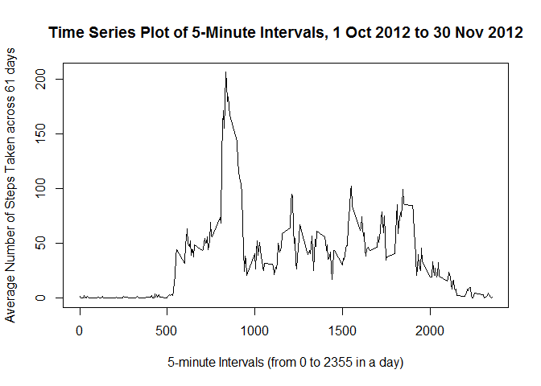

```r
ds<-aggregate(data$steps,by=list(interval=data$interval),FUN=mean, na.rm=TRUE)

plot(ds[,1],ds[,2],type="l",main="Time Series Plot of 5-Minute Intervals, 1 Oct 2012 to 30 Nov 2012",xlab="5-minute Intervals (from 0 to 2355 in a day)",ylab="Average Number of Steps Taken across 61 days" )
```

Finding interval with the Highest average number of steps taken:

```r
which.max(ds[,2])
```

```
## [1] 104
```

```r
ds[104,1]
```

```
## [1] 835
```

```r
ds[104,2]
```

```
## [1] 206.1698
```

Interval with the highest average number of steps of 206.1698 is: **0835-0840 hrs**

## Imputing Missing Values

1)Total number of rows with NAs is:

```r
sum(!complete.cases(data))
```

```
## [1] 2304
```

2. Imputing missing values with the **mean of the 5-minute interval across all the 61 days** and
3. Creating a newdataset “newdata” equal to the original dataset “data” but with the missing data filled in

```r
impute<-function(x,fun){
  missing<-is.na(x)
  replace(x,missing,fun(x[!missing]))
}
newdata<-ddply(data,~interval,transform,steps=impute(steps,mean))
newdata<-arrange(newdata,date)
```

4. Histogram of the Total Number of Steps Taken Daily for the New Dataset (with imputed missing values)

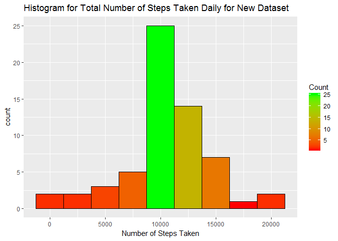

```r
dfnew<-aggregate(newdata$steps, by=list(date=newdata$date),FUN=sum, na.rm=TRUE)

g<-ggplot(data=dfnew,aes(x))+
  geom_histogram(col="black",aes(fill=..count..),binwidth = 2500)+
  scale_fill_gradient("Count",low="red",high="green")+
  labs(title="Histogram for Total Number of Steps Taken Daily for New Dataset",x="Number of Steps Taken")

print(g)
```

4a) Mean number of steps taken daily for new dataset

```r
mean(dfnew$x)
```

```
## [1] 10766.19
```

4b) Median number of steps taken daily for new dataset

```r
median(dfnew$x)
```

```
## [1] 10766.19
```

The mean and median estimates for the new dataset differ from the initial estimates.

By imputing the missing values for each interval with the average across the 61 days, the mean is now moved close/equal to the median for the new dataset.